# Risk Factor Analysis

## Outcome Variable

**Outcome Variable:** ever_wasted

## Predictor Variables

**Intervention Variable:** mwtkg

**Adjustment Set:**

unadjusted

## Stratifying Variables

The analysis was stratified on these variable(s):

- agecat
- studyid
- country

## Data Summary

| agecat | studyid | country | mwtkg | ever_wasted | n_cell | n |
| --- | --- | --- | --- | --- | --- | --- |
| 0-24 months | ki0047075b-MAL-ED | BANGLADESH | >=58 kg | 0 | 39 | 254 |
| 0-24 months | ki0047075b-MAL-ED | BANGLADESH | >=58 kg | 1 | 9 | 254 |
| 0-24 months | ki0047075b-MAL-ED | BANGLADESH | <52 kg | 0 | 97 | 254 |
| 0-24 months | ki0047075b-MAL-ED | BANGLADESH | <52 kg | 1 | 65 | 254 |
| 0-24 months | ki0047075b-MAL-ED | BANGLADESH | [52-58) kg | 0 | 33 | 254 |
| 0-24 months | ki0047075b-MAL-ED | BANGLADESH | [52-58) kg | 1 | 11 | 254 |
| 0-24 months | ki0047075b-MAL-ED | BRAZIL | >=58 kg | 0 | 132 | 221 |
| 0-24 months | ki0047075b-MAL-ED | BRAZIL | >=58 kg | 1 | 11 | 221 |
| 0-24 months | ki0047075b-MAL-ED | BRAZIL | <52 kg | 0 | 40 | 221 |
| 0-24 months | ki0047075b-MAL-ED | BRAZIL | <52 kg | 1 | 2 | 221 |
| 0-24 months | ki0047075b-MAL-ED | BRAZIL | [52-58) kg | 0 | 30 | 221 |
| 0-24 months | ki0047075b-MAL-ED | BRAZIL | [52-58) kg | 1 | 6 | 221 |
| 0-24 months | ki0047075b-MAL-ED | INDIA | >=58 kg | 0 | 33 | 242 |
| 0-24 months | ki0047075b-MAL-ED | INDIA | >=58 kg | 1 | 9 | 242 |
| 0-24 months | ki0047075b-MAL-ED | INDIA | <52 kg | 0 | 66 | 242 |
| 0-24 months | ki0047075b-MAL-ED | INDIA | <52 kg | 1 | 84 | 242 |
| 0-24 months | ki0047075b-MAL-ED | INDIA | [52-58) kg | 0 | 28 | 242 |
| 0-24 months | ki0047075b-MAL-ED | INDIA | [52-58) kg | 1 | 22 | 242 |
| 0-24 months | ki0047075b-MAL-ED | NEPAL | >=58 kg | 0 | 67 | 238 |
| 0-24 months | ki0047075b-MAL-ED | NEPAL | >=58 kg | 1 | 13 | 238 |
| 0-24 months | ki0047075b-MAL-ED | NEPAL | <52 kg | 0 | 39 | 238 |
| 0-24 months | ki0047075b-MAL-ED | NEPAL | <52 kg | 1 | 37 | 238 |
| 0-24 months | ki0047075b-MAL-ED | NEPAL | [52-58) kg | 0 | 63 | 238 |
| 0-24 months | ki0047075b-MAL-ED | NEPAL | [52-58) kg | 1 | 19 | 238 |
| 0-24 months | ki0047075b-MAL-ED | PERU | >=58 kg | 0 | 96 | 290 |
| 0-24 months | ki0047075b-MAL-ED | PERU | >=58 kg | 1 | 8 | 290 |
| 0-24 months | ki0047075b-MAL-ED | PERU | <52 kg | 0 | 102 | 290 |
| 0-24 months | ki0047075b-MAL-ED | PERU | <52 kg | 1 | 13 | 290 |
| 0-24 months | ki0047075b-MAL-ED | PERU | [52-58) kg | 0 | 66 | 290 |
| 0-24 months | ki0047075b-MAL-ED | PERU | [52-58) kg | 1 | 5 | 290 |

[output cut: 252 more lines]

The following strata were considered:

- agecat: 0-24 months, studyid: ki0047075b-MAL-ED, country: BANGLADESH
- agecat: 0-24 months, studyid: ki0047075b-MAL-ED, country: BRAZIL
- agecat: 0-24 months, studyid: ki0047075b-MAL-ED, country: INDIA
- agecat: 0-24 months, studyid: ki0047075b-MAL-ED, country: NEPAL
- agecat: 0-24 months, studyid: ki0047075b-MAL-ED, country: PERU
- agecat: 0-24 months, studyid: ki0047075b-MAL-ED, country: SOUTH AFRICA
- agecat: 0-24 months, studyid: ki0047075b-MAL-ED, country: TANZANIA, UNITED REPUBLIC OF
- agecat: 0-24 months, studyid: ki1000304b-SAS-CompFeed, country: INDIA
- agecat: 0-24 months, studyid: ki1017093-NIH-Birth, country: BANGLADESH
- agecat: 0-24 months, studyid: ki1017093b-PROVIDE, country: BANGLADESH
- agecat: 0-24 months, studyid: ki1017093c-NIH-Crypto, country: BANGLADESH
- agecat: 0-24 months, studyid: ki1066203-TanzaniaChild2, country: TANZANIA, UNITED REPUBLIC OF
- agecat: 0-24 months, studyid: ki1112895-iLiNS-Zinc, country: BURKINA FASO
- agecat: 0-24 months, studyid: ki1119695-PROBIT, country: BELARUS
- agecat: 0-24 months, studyid: ki1126311-ZVITAMBO, country: ZIMBABWE
- agecat: 0-24 months, studyid: ki1148112-LCNI-5, country: MALAWI
- agecat: 0-6 months, studyid: ki0047075b-MAL-ED, country: BANGLADESH
- agecat: 0-6 months, studyid: ki0047075b-MAL-ED, country: BRAZIL
- agecat: 0-6 months, studyid: ki0047075b-MAL-ED, country: INDIA
- agecat: 0-6 months, studyid: ki0047075b-MAL-ED, country: NEPAL
- agecat: 0-6 months, studyid: ki0047075b-MAL-ED, country: PERU
- agecat: 0-6 months, studyid: ki0047075b-MAL-ED, country: SOUTH AFRICA
- agecat: 0-6 months, studyid: ki0047075b-MAL-ED, country: TANZANIA, UNITED REPUBLIC OF
- agecat: 0-6 months, studyid: ki1000304b-SAS-CompFeed, country: INDIA
- agecat: 0-6 months, studyid: ki1017093-NIH-Birth, country: BANGLADESH
- agecat: 0-6 months, studyid: ki1017093b-PROVIDE, country: BANGLADESH
- agecat: 0-6 months, studyid: ki1017093c-NIH-Crypto, country: BANGLADESH
- agecat: 0-6 months, studyid: ki1066203-TanzaniaChild2, country: TANZANIA, UNITED REPUBLIC OF
- agecat: 0-6 months, studyid: ki1119695-PROBIT, country: BELARUS
- agecat: 0-6 months, studyid: ki1126311-ZVITAMBO, country: ZIMBABWE
- agecat: 0-6 months, studyid: ki1148112-LCNI-5, country: MALAWI
- agecat: 6-24 months, studyid: ki0047075b-MAL-ED, country: BANGLADESH
- agecat: 6-24 months, studyid: ki0047075b-MAL-ED, country: BRAZIL
- agecat: 6-24 months, studyid: ki0047075b-MAL-ED, country: INDIA
- agecat: 6-24 months, studyid: ki0047075b-MAL-ED, country: NEPAL
- agecat: 6-24 months, studyid: ki0047075b-MAL-ED, country: PERU
- agecat: 6-24 months, studyid: ki0047075b-MAL-ED, country: SOUTH AFRICA
- agecat: 6-24 months, studyid: ki0047075b-MAL-ED, country: TANZANIA, UNITED REPUBLIC OF
- agecat: 6-24 months, studyid: ki1000304b-SAS-CompFeed, country: INDIA
- agecat: 6-24 months, studyid: ki1017093-NIH-Birth, country: BANGLADESH
- agecat: 6-24 months, studyid: ki1017093b-PROVIDE, country: BANGLADESH
- agecat: 6-24 months, studyid: ki1017093c-NIH-Crypto, country: BANGLADESH
- agecat: 6-24 months, studyid: ki1066203-TanzaniaChild2, country: TANZANIA, UNITED REPUBLIC OF
- agecat: 6-24 months, studyid: ki1112895-iLiNS-Zinc, country: BURKINA FASO
- agecat: 6-24 months, studyid: ki1119695-PROBIT, country: BELARUS
- agecat: 6-24 months, studyid: ki1126311-ZVITAMBO, country: ZIMBABWE
- agecat: 6-24 months, studyid: ki1148112-LCNI-5, country: MALAWI

### Dropped Strata

Some strata were dropped due to rare outcomes:

- agecat: 0-24 months, studyid: ki0047075b-MAL-ED, country: BRAZIL
- agecat: 0-6 months, studyid: ki0047075b-MAL-ED, country: BRAZIL
- agecat: 0-6 months, studyid: ki0047075b-MAL-ED, country: PERU
- agecat: 0-6 months, studyid: ki0047075b-MAL-ED, country: SOUTH AFRICA
- agecat: 0-6 months, studyid: ki0047075b-MAL-ED, country: TANZANIA, UNITED REPUBLIC OF
- agecat: 0-6 months, studyid: ki1148112-LCNI-5, country: MALAWI
- agecat: 6-24 months, studyid: ki0047075b-MAL-ED, country: BANGLADESH
- agecat: 6-24 months, studyid: ki0047075b-MAL-ED, country: BRAZIL
- agecat: 6-24 months, studyid: ki0047075b-MAL-ED, country: INDIA
- agecat: 6-24 months, studyid: ki0047075b-MAL-ED, country: PERU
- agecat: 6-24 months, studyid: ki0047075b-MAL-ED, country: SOUTH AFRICA
- agecat: 6-24 months, studyid: ki0047075b-MAL-ED, country: TANZANIA, UNITED REPUBLIC OF

## Methods Detail

We’re interested in the causal parameters $E[Y_a]$ for all values of $a \in \mathcal{A}$. These parameters represent the mean outcome if, possibly contrary to fact, we intervened to set all units to have $A=a$. Under the randomization and positivity assumptions, these are identified by the statistical parameters $\psi_a=E_W[E_{Y|A,W}(Y|A=a,W)]$. In addition, we’re interested in the mean of $Y$, $E[Y]$ under no intervention (the observed mean). We will estimate these parameters by using SuperLearner to fit the relevant likelihood factors – $E_{Y|A,W}(Y|A=a,W)$ and $p(A=a|W)$, and then updating our likelihood fit using a joint TMLE.

For unadjusted analyses ($W=\{\}$), initial likelihoods were estimated using Lrnr_glm to estimate the simple $E(Y|A)$ and Lrnr_mean to estimate $p(A)$. For adjusted analyses, a small library containing Lrnr_glmnet, Lrnr_xgboost, and Lrnr_mean was used.

Having estimated these parameters, we will then use the delta method to estimate relative risks and attributable risks relative to a prespecified baseline level of $A$.

# Results Detail

## Results Plots

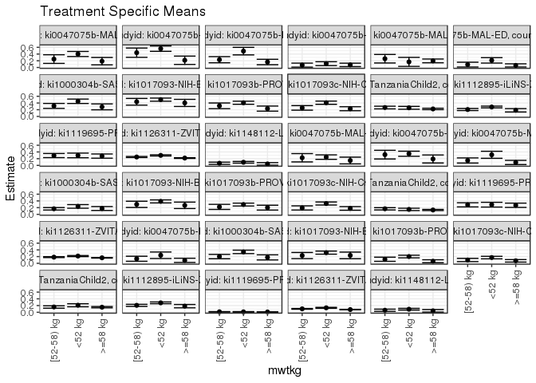

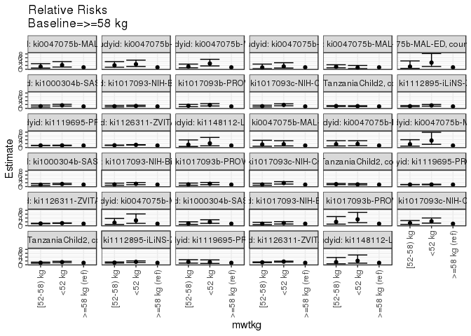

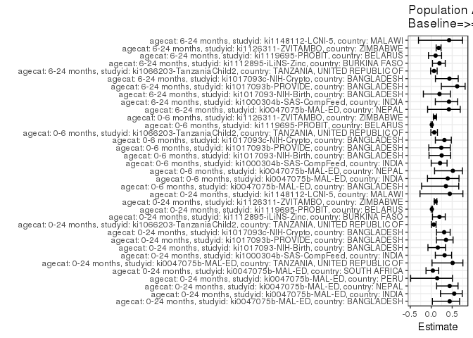

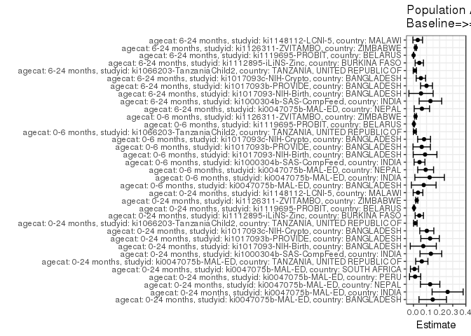

## Results Table

### Parameter: TSM

| agecat | studyid | country | intervention_level | baseline_level | estimate | ci_lower | ci_upper |
| --- | --- | --- | --- | --- | --- | --- | --- |
| 0-24 months | ki0047075b-MAL-ED | BANGLADESH | >=58 kg | NA | 0.1875000 | 0.0768640 | 0.2981360 |
| 0-24 months | ki0047075b-MAL-ED | BANGLADESH | <52 kg | NA | 0.4012346 | 0.3256079 | 0.4768612 |
| 0-24 months | ki0047075b-MAL-ED | BANGLADESH | [52-58) kg | NA | 0.2500000 | 0.1218027 | 0.3781973 |
| 0-24 months | ki0047075b-MAL-ED | INDIA | >=58 kg | NA | 0.2142857 | 0.0899341 | 0.3386374 |
| 0-24 months | ki0047075b-MAL-ED | INDIA | <52 kg | NA | 0.5600000 | 0.4803984 | 0.6396016 |
| 0-24 months | ki0047075b-MAL-ED | INDIA | [52-58) kg | NA | 0.4400000 | 0.3021259 | 0.5778741 |
| 0-24 months | ki0047075b-MAL-ED | NEPAL | >=58 kg | NA | 0.1625000 | 0.0814904 | 0.2435096 |
| 0-24 months | ki0047075b-MAL-ED | NEPAL | <52 kg | NA | 0.4868421 | 0.3742326 | 0.5994516 |
| 0-24 months | ki0047075b-MAL-ED | NEPAL | [52-58) kg | NA | 0.2317073 | 0.1401931 | 0.3232216 |
| 0-24 months | ki0047075b-MAL-ED | PERU | >=58 kg | NA | 0.0769231 | 0.0256217 | 0.1282244 |
| 0-24 months | ki0047075b-MAL-ED | PERU | <52 kg | NA | 0.1130435 | 0.0550708 | 0.1710161 |
| 0-24 months | ki0047075b-MAL-ED | PERU | [52-58) kg | NA | 0.0704225 | 0.0108059 | 0.1300392 |
| 0-24 months | ki0047075b-MAL-ED | SOUTH AFRICA | >=58 kg | NA | 0.1958763 | 0.1399256 | 0.2518270 |
| 0-24 months | ki0047075b-MAL-ED | SOUTH AFRICA | <52 kg | NA | 0.1666667 | 0.0330604 | 0.3002730 |
| 0-24 months | ki0047075b-MAL-ED | SOUTH AFRICA | [52-58) kg | NA | 0.2608696 | 0.1337398 | 0.3879993 |
| 0-24 months | ki0047075b-MAL-ED | TANZANIA, UNITED REPUBLIC OF | >=58 kg | NA | 0.0612245 | 0.0136660 | 0.1087830 |
| 0-24 months | ki0047075b-MAL-ED | TANZANIA, UNITED REPUBLIC OF | <52 kg | NA | 0.2121212 | 0.1314345 | 0.2928079 |
| 0-24 months | ki0047075b-MAL-ED | TANZANIA, UNITED REPUBLIC OF | [52-58) kg | NA | 0.0847458 | 0.0135422 | 0.1559493 |
| 0-24 months | ki1000304b-SAS-CompFeed | INDIA | >=58 kg | NA | 0.2844037 | 0.1966022 | 0.3722051 |
| 0-24 months | ki1000304b-SAS-CompFeed | INDIA | <52 kg | NA | 0.4513889 | 0.3856278 | 0.5171500 |
| 0-24 months | ki1000304b-SAS-CompFeed | INDIA | [52-58) kg | NA | 0.3135593 | 0.2399261 | 0.3871925 |
| 0-24 months | ki1017093-NIH-Birth | BANGLADESH | >=58 kg | NA | 0.4024390 | 0.2962131 | 0.5086650 |
| 0-24 months | ki1017093-NIH-Birth | BANGLADESH | <52 kg | NA | 0.5000000 | 0.4536631 | 0.5463369 |
| 0-24 months | ki1017093-NIH-Birth | BANGLADESH | [52-58) kg | NA | 0.4361702 | 0.3358394 | 0.5365011 |
| 0-24 months | ki1017093b-PROVIDE | BANGLADESH | >=58 kg | NA | 0.2333333 | 0.1576023 | 0.3090644 |
| 0-24 months | ki1017093b-PROVIDE | BANGLADESH | <52 kg | NA | 0.4074074 | 0.3610388 | 0.4537760 |
| 0-24 months | ki1017093b-PROVIDE | BANGLADESH | [52-58) kg | NA | 0.3162393 | 0.2319175 | 0.4005611 |
| 0-24 months | ki1017093c-NIH-Crypto | BANGLADESH | >=58 kg | NA | 0.2291667 | 0.1696770 | 0.2886563 |
| 0-24 months | ki1017093c-NIH-Crypto | BANGLADESH | <52 kg | NA | 0.4088670 | 0.3610143 | 0.4567197 |
| 0-24 months | ki1017093c-NIH-Crypto | BANGLADESH | [52-58) kg | NA | 0.2547771 | 0.1865731 | 0.3229810 |

[output cut: 75 more lines]

### Parameter: E(Y)

| agecat | studyid | country | intervention_level | baseline_level | estimate | ci_lower | ci_upper |
| --- | --- | --- | --- | --- | --- | --- | --- |
| 0-24 months | ki0047075b-MAL-ED | BANGLADESH | NA | NA | 0.3346457 | 0.2765014 | 0.3927899 |
| 0-24 months | ki0047075b-MAL-ED | INDIA | NA | NA | 0.4752066 | 0.4121581 | 0.5382551 |
| 0-24 months | ki0047075b-MAL-ED | NEPAL | NA | NA | 0.2899160 | 0.2321510 | 0.3476810 |
| 0-24 months | ki0047075b-MAL-ED | PERU | NA | NA | 0.0896552 | 0.0567177 | 0.1225926 |
| 0-24 months | ki0047075b-MAL-ED | SOUTH AFRICA | NA | NA | 0.2037037 | 0.1555745 | 0.2518329 |
| 0-24 months | ki0047075b-MAL-ED | TANZANIA, UNITED REPUBLIC OF | NA | NA | 0.1250000 | 0.0844083 | 0.1655917 |
| 0-24 months | ki1000304b-SAS-CompFeed | INDIA | NA | NA | 0.4175017 | 0.3589990 | 0.4760043 |
| 0-24 months | ki1017093-NIH-Birth | BANGLADESH | NA | NA | 0.4775641 | 0.4383415 | 0.5167867 |
| 0-24 months | ki1017093b-PROVIDE | BANGLADESH | NA | NA | 0.3602392 | 0.3238339 | 0.3966444 |
| 0-24 months | ki1017093c-NIH-Crypto | BANGLADESH | NA | NA | 0.3311258 | 0.2975342 | 0.3647175 |
| 0-24 months | ki1066203-TanzaniaChild2 | TANZANIA, UNITED REPUBLIC OF | NA | NA | 0.2372449 | 0.2200495 | 0.2544403 |
| 0-24 months | ki1112895-iLiNS-Zinc | BURKINA FASO | NA | NA | 0.2271869 | 0.2003867 | 0.2539871 |
| 0-24 months | ki1119695-PROBIT | BELARUS | NA | NA | 0.2816584 | 0.2197582 | 0.3435586 |
| 0-24 months | ki1126311-ZVITAMBO | ZIMBABWE | NA | NA | 0.2438216 | 0.2358577 | 0.2517856 |
| 0-24 months | ki1148112-LCNI-5 | MALAWI | NA | NA | 0.0787590 | 0.0605107 | 0.0970072 |
| 0-6 months | ki0047075b-MAL-ED | BANGLADESH | NA | NA | 0.2244094 | 0.1730022 | 0.2758167 |
| 0-6 months | ki0047075b-MAL-ED | INDIA | NA | NA | 0.3140496 | 0.2554513 | 0.3726479 |
| 0-6 months | ki0047075b-MAL-ED | NEPAL | NA | NA | 0.1806723 | 0.1316889 | 0.2296556 |
| 0-6 months | ki1000304b-SAS-CompFeed | INDIA | NA | NA | 0.2208054 | 0.1758216 | 0.2657892 |
| 0-6 months | ki1017093-NIH-Birth | BANGLADESH | NA | NA | 0.3569132 | 0.3192325 | 0.3945938 |
| 0-6 months | ki1017093b-PROVIDE | BANGLADESH | NA | NA | 0.2630792 | 0.2296894 | 0.2964690 |
| 0-6 months | ki1017093c-NIH-Crypto | BANGLADESH | NA | NA | 0.2582781 | 0.2270370 | 0.2895193 |
| 0-6 months | ki1066203-TanzaniaChild2 | TANZANIA, UNITED REPUBLIC OF | NA | NA | 0.1403061 | 0.1262673 | 0.1543450 |
| 0-6 months | ki1119695-PROBIT | BELARUS | NA | NA | 0.2746152 | 0.2119692 | 0.3372611 |
| 0-6 months | ki1126311-ZVITAMBO | ZIMBABWE | NA | NA | 0.1803706 | 0.1732226 | 0.1875186 |
| 6-24 months | ki0047075b-MAL-ED | NEPAL | NA | NA | 0.1531915 | 0.1070438 | 0.1993392 |
| 6-24 months | ki1000304b-SAS-CompFeed | INDIA | NA | NA | 0.3062998 | 0.2626026 | 0.3499970 |
| 6-24 months | ki1017093-NIH-Birth | BANGLADESH | NA | NA | 0.2939002 | 0.2554778 | 0.3323226 |
| 6-24 months | ki1017093b-PROVIDE | BANGLADESH | NA | NA | 0.1612378 | 0.1321259 | 0.1903497 |
| 6-24 months | ki1017093c-NIH-Crypto | BANGLADESH | NA | NA | 0.1315068 | 0.1069744 | 0.1560393 |
| 6-24 months | ki1066203-TanzaniaChild2 | TANZANIA, UNITED REPUBLIC OF | NA | NA | 0.1612740 | 0.1450620 | 0.1774860 |
| 6-24 months | ki1112895-iLiNS-Zinc | BURKINA FASO | NA | NA | 0.2271869 | 0.2003867 | 0.2539871 |
| 6-24 months | ki1119695-PROBIT | BELARUS | NA | NA | 0.0103168 | 0.0071373 | 0.0134962 |
| 6-24 months | ki1126311-ZVITAMBO | ZIMBABWE | NA | NA | 0.0973196 | 0.0914209 | 0.1032182 |
| 6-24 months | ki1148112-LCNI-5 | MALAWI | NA | NA | 0.0764563 | 0.0583018 | 0.0946108 |

### Parameter: RR

| agecat | studyid | country | intervention_level | baseline_level | estimate | ci_lower | ci_upper |
| --- | --- | --- | --- | --- | --- | --- | --- |
| 0-24 months | ki0047075b-MAL-ED | BANGLADESH | >=58 kg | >=58 kg | 1.0000000 | 1.0000000 | 1.000000 |
| 0-24 months | ki0047075b-MAL-ED | BANGLADESH | <52 kg | >=58 kg | 2.1399177 | 1.1518112 | 3.975693 |
| 0-24 months | ki0047075b-MAL-ED | BANGLADESH | [52-58) kg | >=58 kg | 1.3333333 | 0.6101437 | 2.913704 |
| 0-24 months | ki0047075b-MAL-ED | INDIA | >=58 kg | >=58 kg | 1.0000000 | 1.0000000 | 1.000000 |
| 0-24 months | ki0047075b-MAL-ED | INDIA | <52 kg | >=58 kg | 2.6133333 | 1.4378705 | 4.749740 |
| 0-24 months | ki0047075b-MAL-ED | INDIA | [52-58) kg | >=58 kg | 2.0533333 | 1.0617947 | 3.970803 |
| 0-24 months | ki0047075b-MAL-ED | NEPAL | >=58 kg | >=58 kg | 1.0000000 | 1.0000000 | 1.000000 |
| 0-24 months | ki0047075b-MAL-ED | NEPAL | <52 kg | >=58 kg | 2.9959514 | 1.7292600 | 5.190501 |
| 0-24 months | ki0047075b-MAL-ED | NEPAL | [52-58) kg | >=58 kg | 1.4258912 | 0.7548649 | 2.693417 |
| 0-24 months | ki0047075b-MAL-ED | PERU | >=58 kg | >=58 kg | 1.0000000 | 1.0000000 | 1.000000 |
| 0-24 months | ki0047075b-MAL-ED | PERU | <52 kg | >=58 kg | 1.4695652 | 0.6336052 | 3.408466 |
| 0-24 months | ki0047075b-MAL-ED | PERU | [52-58) kg | >=58 kg | 0.9154930 | 0.3116133 | 2.689640 |
| 0-24 months | ki0047075b-MAL-ED | SOUTH AFRICA | >=58 kg | >=58 kg | 1.0000000 | 1.0000000 | 1.000000 |
| 0-24 months | ki0047075b-MAL-ED | SOUTH AFRICA | <52 kg | >=58 kg | 0.8508772 | 0.3633111 | 1.992760 |
| 0-24 months | ki0047075b-MAL-ED | SOUTH AFRICA | [52-58) kg | >=58 kg | 1.3318078 | 0.7570416 | 2.342952 |
| 0-24 months | ki0047075b-MAL-ED | TANZANIA, UNITED REPUBLIC OF | >=58 kg | >=58 kg | 1.0000000 | 1.0000000 | 1.000000 |
| 0-24 months | ki0047075b-MAL-ED | TANZANIA, UNITED REPUBLIC OF | <52 kg | >=58 kg | 3.4646465 | 1.4589079 | 8.227918 |
| 0-24 months | ki0047075b-MAL-ED | TANZANIA, UNITED REPUBLIC OF | [52-58) kg | >=58 kg | 1.3841808 | 0.4408035 | 4.346509 |
| 0-24 months | ki1000304b-SAS-CompFeed | INDIA | >=58 kg | >=58 kg | 1.0000000 | 1.0000000 | 1.000000 |
| 0-24 months | ki1000304b-SAS-CompFeed | INDIA | <52 kg | >=58 kg | 1.5871416 | 1.1929861 | 2.111524 |
| 0-24 months | ki1000304b-SAS-CompFeed | INDIA | [52-58) kg | >=58 kg | 1.1025150 | 0.7210266 | 1.685846 |
| 0-24 months | ki1017093-NIH-Birth | BANGLADESH | >=58 kg | >=58 kg | 1.0000000 | 1.0000000 | 1.000000 |
| 0-24 months | ki1017093-NIH-Birth | BANGLADESH | <52 kg | >=58 kg | 1.2424242 | 0.9392374 | 1.643480 |
| 0-24 months | ki1017093-NIH-Birth | BANGLADESH | [52-58) kg | >=58 kg | 1.0838169 | 0.7636604 | 1.538196 |
| 0-24 months | ki1017093b-PROVIDE | BANGLADESH | >=58 kg | >=58 kg | 1.0000000 | 1.0000000 | 1.000000 |
| 0-24 months | ki1017093b-PROVIDE | BANGLADESH | <52 kg | >=58 kg | 1.7460317 | 1.2378883 | 2.462764 |
| 0-24 months | ki1017093b-PROVIDE | BANGLADESH | [52-58) kg | >=58 kg | 1.3553114 | 0.8904640 | 2.062822 |
| 0-24 months | ki1017093c-NIH-Crypto | BANGLADESH | >=58 kg | >=58 kg | 1.0000000 | 1.0000000 | 1.000000 |
| 0-24 months | ki1017093c-NIH-Crypto | BANGLADESH | <52 kg | >=58 kg | 1.7841469 | 1.3420330 | 2.371909 |
| 0-24 months | ki1017093c-NIH-Crypto | BANGLADESH | [52-58) kg | >=58 kg | 1.1117545 | 0.7657067 | 1.614193 |

[output cut: 75 more lines]

### Parameter: PAR

| agecat | studyid | country | intervention_level | baseline_level | estimate | ci_lower | ci_upper |
| --- | --- | --- | --- | --- | --- | --- | --- |
| 0-24 months | ki0047075b-MAL-ED | BANGLADESH | >=58 kg | NA | 0.1471457 | 0.0422895 | 0.2520018 |
| 0-24 months | ki0047075b-MAL-ED | INDIA | >=58 kg | NA | 0.2609209 | 0.1422996 | 0.3795422 |
| 0-24 months | ki0047075b-MAL-ED | NEPAL | >=58 kg | NA | 0.1274160 | 0.0533380 | 0.2014940 |
| 0-24 months | ki0047075b-MAL-ED | PERU | >=58 kg | NA | 0.0127321 | -0.0300353 | 0.0554995 |
| 0-24 months | ki0047075b-MAL-ED | SOUTH AFRICA | >=58 kg | NA | 0.0078274 | -0.0229668 | 0.0386217 |
| 0-24 months | ki0047075b-MAL-ED | TANZANIA, UNITED REPUBLIC OF | >=58 kg | NA | 0.0637755 | 0.0171086 | 0.1104424 |
| 0-24 months | ki1000304b-SAS-CompFeed | INDIA | >=58 kg | NA | 0.1330980 | 0.0501065 | 0.2160895 |
| 0-24 months | ki1017093-NIH-Birth | BANGLADESH | >=58 kg | NA | 0.0751251 | -0.0241559 | 0.1744060 |
| 0-24 months | ki1017093b-PROVIDE | BANGLADESH | >=58 kg | NA | 0.1269058 | 0.0561735 | 0.1976382 |
| 0-24 months | ki1017093c-NIH-Crypto | BANGLADESH | >=58 kg | NA | 0.1019592 | 0.0484107 | 0.1555076 |
| 0-24 months | ki1066203-TanzaniaChild2 | TANZANIA, UNITED REPUBLIC OF | >=58 kg | NA | 0.0143452 | 0.0009053 | 0.0277850 |
| 0-24 months | ki1112895-iLiNS-Zinc | BURKINA FASO | >=58 kg | NA | 0.0445876 | 0.0129305 | 0.0762446 |
| 0-24 months | ki1119695-PROBIT | BELARUS | >=58 kg | NA | 0.0041995 | 0.0000900 | 0.0083091 |
| 0-24 months | ki1126311-ZVITAMBO | ZIMBABWE | >=58 kg | NA | 0.0253400 | 0.0176835 | 0.0329965 |
| 0-24 months | ki1148112-LCNI-5 | MALAWI | >=58 kg | NA | 0.0348993 | -0.0020178 | 0.0718164 |
| 0-6 months | ki0047075b-MAL-ED | BANGLADESH | >=58 kg | NA | 0.0785761 | -0.0155963 | 0.1727486 |
| 0-6 months | ki0047075b-MAL-ED | INDIA | >=58 kg | NA | 0.1235734 | 0.0109686 | 0.2361782 |
| 0-6 months | ki0047075b-MAL-ED | NEPAL | >=58 kg | NA | 0.0931723 | 0.0326646 | 0.1536799 |
| 0-6 months | ki1000304b-SAS-CompFeed | INDIA | >=58 kg | NA | 0.0464934 | 0.0053360 | 0.0876509 |
| 0-6 months | ki1017093-NIH-Birth | BANGLADESH | >=58 kg | NA | 0.0886205 | -0.0019473 | 0.1791883 |
| 0-6 months | ki1017093b-PROVIDE | BANGLADESH | >=58 kg | NA | 0.0630792 | -0.0032855 | 0.1294439 |
| 0-6 months | ki1017093c-NIH-Crypto | BANGLADESH | >=58 kg | NA | 0.0811948 | 0.0320969 | 0.1302928 |
| 0-6 months | ki1066203-TanzaniaChild2 | TANZANIA, UNITED REPUBLIC OF | >=58 kg | NA | 0.0102248 | -0.0008172 | 0.0212669 |
| 0-6 months | ki1119695-PROBIT | BELARUS | >=58 kg | NA | 0.0033826 | -0.0010049 | 0.0077700 |
| 0-6 months | ki1126311-ZVITAMBO | ZIMBABWE | >=58 kg | NA | 0.0160603 | 0.0091949 | 0.0229257 |
| 6-24 months | ki0047075b-MAL-ED | NEPAL | >=58 kg | NA | 0.0645839 | 0.0060879 | 0.1230799 |
| 6-24 months | ki1000304b-SAS-CompFeed | INDIA | >=58 kg | NA | 0.1298292 | 0.0437584 | 0.2159000 |
| 6-24 months | ki1017093-NIH-Birth | BANGLADESH | >=58 kg | NA | 0.0577891 | -0.0346823 | 0.1502605 |
| 6-24 months | ki1017093b-PROVIDE | BANGLADESH | >=58 kg | NA | 0.0998343 | 0.0543326 | 0.1453359 |
| 6-24 months | ki1017093c-NIH-Crypto | BANGLADESH | >=58 kg | NA | 0.0570388 | 0.0211819 | 0.0928957 |
| 6-24 months | ki1066203-TanzaniaChild2 | TANZANIA, UNITED REPUBLIC OF | >=58 kg | NA | 0.0106764 | -0.0018722 | 0.0232250 |
| 6-24 months | ki1112895-iLiNS-Zinc | BURKINA FASO | >=58 kg | NA | 0.0445876 | 0.0129305 | 0.0762446 |
| 6-24 months | ki1119695-PROBIT | BELARUS | >=58 kg | NA | 0.0010683 | -0.0004570 | 0.0025937 |
| 6-24 months | ki1126311-ZVITAMBO | ZIMBABWE | >=58 kg | NA | 0.0172555 | 0.0115032 | 0.0230078 |
| 6-24 months | ki1148112-LCNI-5 | MALAWI | >=58 kg | NA | 0.0325967 | -0.0041856 | 0.0693789 |

### Parameter: PAF

| agecat | studyid | country | intervention_level | baseline_level | estimate | ci_lower | ci_upper |
| --- | --- | --- | --- | --- | --- | --- | --- |
| 0-24 months | ki0047075b-MAL-ED | BANGLADESH | >=58 kg | NA | 0.4397059 | 0.0269915 | 0.6773620 |
| 0-24 months | ki0047075b-MAL-ED | INDIA | >=58 kg | NA | 0.5490683 | 0.2190253 | 0.7396338 |
| 0-24 months | ki0047075b-MAL-ED | NEPAL | >=58 kg | NA | 0.4394928 | 0.1287317 | 0.6394126 |
| 0-24 months | ki0047075b-MAL-ED | PERU | >=58 kg | NA | 0.1420118 | -0.4918851 | 0.5065681 |
| 0-24 months | ki0047075b-MAL-ED | SOUTH AFRICA | >=58 kg | NA | 0.0384255 | -0.1251152 | 0.1781948 |
| 0-24 months | ki0047075b-MAL-ED | TANZANIA, UNITED REPUBLIC OF | >=58 kg | NA | 0.5102041 | 0.0189072 | 0.7554767 |
| 0-24 months | ki1000304b-SAS-CompFeed | INDIA | >=58 kg | NA | 0.3187963 | 0.0973921 | 0.4858915 |
| 0-24 months | ki1017093-NIH-Birth | BANGLADESH | >=58 kg | NA | 0.1573089 | -0.0787476 | 0.3417104 |
| 0-24 months | ki1017093b-PROVIDE | BANGLADESH | >=58 kg | NA | 0.3522822 | 0.1241081 | 0.5210158 |
| 0-24 months | ki1017093c-NIH-Crypto | BANGLADESH | >=58 kg | NA | 0.3079167 | 0.1269471 | 0.4513742 |
| 0-24 months | ki1066203-TanzaniaChild2 | TANZANIA, UNITED REPUBLIC OF | >=58 kg | NA | 0.0604657 | 0.0021480 | 0.1153750 |
| 0-24 months | ki1112895-iLiNS-Zinc | BURKINA FASO | >=58 kg | NA | 0.1962593 | 0.0293775 | 0.3344487 |
| 0-24 months | ki1119695-PROBIT | BELARUS | >=58 kg | NA | 0.0149100 | -0.0005939 | 0.0301737 |
| 0-24 months | ki1126311-ZVITAMBO | ZIMBABWE | >=58 kg | NA | 0.1039285 | 0.0720500 | 0.1347118 |
| 0-24 months | ki1148112-LCNI-5 | MALAWI | >=58 kg | NA | 0.4431153 | -0.2685075 | 0.7555233 |
| 0-6 months | ki0047075b-MAL-ED | BANGLADESH | >=58 kg | NA | 0.3501462 | -0.2304051 | 0.6567716 |
| 0-6 months | ki0047075b-MAL-ED | INDIA | >=58 kg | NA | 0.3934837 | -0.0893866 | 0.6623219 |
| 0-6 months | ki0047075b-MAL-ED | NEPAL | >=58 kg | NA | 0.5156977 | 0.0793411 | 0.7452382 |
| 0-6 months | ki1000304b-SAS-CompFeed | INDIA | >=58 kg | NA | 0.2105630 | -0.0010937 | 0.3774701 |
| 0-6 months | ki1017093-NIH-Birth | BANGLADESH | >=58 kg | NA | 0.2482971 | -0.0532266 | 0.4634989 |
| 0-6 months | ki1017093b-PROVIDE | BANGLADESH | >=58 kg | NA | 0.2397727 | -0.0582110 | 0.4538466 |
| 0-6 months | ki1017093c-NIH-Crypto | BANGLADESH | >=58 kg | NA | 0.3143697 | 0.0979374 | 0.4788733 |
| 0-6 months | ki1066203-TanzaniaChild2 | TANZANIA, UNITED REPUBLIC OF | >=58 kg | NA | 0.0728751 | -0.0090047 | 0.1481104 |
| 0-6 months | ki1119695-PROBIT | BELARUS | >=58 kg | NA | 0.0123174 | -0.0044277 | 0.0287834 |
| 0-6 months | ki1126311-ZVITAMBO | ZIMBABWE | >=58 kg | NA | 0.0890405 | 0.0502736 | 0.1262250 |
| 6-24 months | ki0047075b-MAL-ED | NEPAL | >=58 kg | NA | 0.4215893 | -0.0867215 | 0.6921392 |
| 6-24 months | ki1000304b-SAS-CompFeed | INDIA | >=58 kg | NA | 0.4238632 | 0.0972969 | 0.6322892 |
| 6-24 months | ki1017093-NIH-Birth | BANGLADESH | >=58 kg | NA | 0.1966282 | -0.1880018 | 0.4567296 |
| 6-24 months | ki1017093b-PROVIDE | BANGLADESH | >=58 kg | NA | 0.6191742 | 0.2410369 | 0.8089126 |
| 6-24 months | ki1017093c-NIH-Crypto | BANGLADESH | >=58 kg | NA | 0.4337323 | 0.0997469 | 0.6438122 |
| 6-24 months | ki1066203-TanzaniaChild2 | TANZANIA, UNITED REPUBLIC OF | >=58 kg | NA | 0.0662004 | -0.0147437 | 0.1406878 |
| 6-24 months | ki1112895-iLiNS-Zinc | BURKINA FASO | >=58 kg | NA | 0.1962593 | 0.0293775 | 0.3344487 |
| 6-24 months | ki1119695-PROBIT | BELARUS | >=58 kg | NA | 0.1035524 | -0.0664498 | 0.2464546 |
| 6-24 months | ki1126311-ZVITAMBO | ZIMBABWE | >=58 kg | NA | 0.1773079 | 0.1168946 | 0.2335884 |
| 6-24 months | ki1148112-LCNI-5 | MALAWI | >=58 kg | NA | 0.4263436 | -0.3046507 | 0.7477626 |